# Cybersecurity Analysis with R

13 April, 2019

## Modern Tools for Cybersecurity

## Outline

- Case Study: ZeuS botnet
  - Background
  - Network Intel Feature Engineering
  - Graph Visualization
- Case Study: Security Incidents
  - VERIS
  - Data preprocessing
  - Retrieval and EDA

## Case Study: ZeuS botnet

## Background

ZeuS: A crimeware kit that **steals credentials** from online services like social networks, online banking accounts, FTP accounts, email accounts and other (phishing)

> This blocklist contains all IPv4 addresses associated with ZeuS C&Cswhich are currently being tracked by ZeuS Tracker

### Tools we’ll use:

- Network Intel
- Graph
- Some domain knowledge

## Network Intel

### Feature Engineering in R

> It’s often said that “data is the fuel of machine learning.” This isn’t quite true: data is like the crude oil of machine learning which means it has to be refined into features — predictor variables — to be useful for training a model. Without relevant features, you can’t train an accurate model, no matter how complex the machine learning algorithm.

## Demo: Raw Data

```r
zeus <- read.csv("data_input/zeus_ipblocklist.txt", skip=5, header=FALSE, col.names="IP", stringsAsFactors = FALSE)
zeus
```

| IP |
| --- |
| 101.200.81.187 |
| 103.19.89.118 |
| 103.230.84.239 |
| 103.4.52.150 |
| 103.7.59.135 |
| 104.247.219.41 |
| 109.127.8.242 |
| 109.229.210.250 |

## Demo: BGP Origin ASN

```r
BulkOrigin("182.253.162.193")
```

```
##      AS              IP       BGP.Prefix CC Registry  Allocated
## 1 17451 182.253.162.193 182.253.162.0/24 ID    apnic 2010-05-10
##                            AS.Name
## 1 BIZNET-AS-AP BIZNET NETWORKS, ID
```

### Lookup for BGP Origin ASN info

```r
BulkOriginASN("AS17451")
```

| AS | CC | Registry | Allocated | AS.Name |
| --- | --- | --- | --- | --- |
| 17451 | ID | apnic | 2000-11-07 | BIZNET-AS-AP BIZNET NETWORKS, ID |

## Demo: Network Intel

From a single list of IP addresses, digital forensics and cybersecurity specialists now have a much richer set of data to build on:

| AS | IP | BGP.Prefix | CC | Registry | Allocated | AS.Name |
| --- | --- | --- | --- | --- | --- | --- |
| 37963 | 101.200.81.187 | 101.200.0.0/16 | CN | apnic | 2011-01-24 | CNNIC-ALIBABA-CN-NET-AP Hangzhou Alibaba Advertising Co.,Ltd., CN |
| 132717 | 103.19.89.118 | 103.19.89.0/24 | IN | apnic | 2013-03-28 | NDCTPL-IN NxtGen Datacenter & Cloud Technologies Pvt. Ltd., IN |
| 132717 | 103.230.84.239 | 103.230.84.0/24 | IN | apnic | 2014-04-29 | NDCTPL-IN NxtGen Datacenter & Cloud Technologies Pvt. Ltd., IN |
| 46062 | 103.4.52.150 | 103.4.52.0/24 | ID | apnic | 2011-05-19 | LINTASBUANA-AS-ID PT. BUANA LINTAS MEDIA, ID |
| 131447 | 103.7.59.135 | 103.7.56.0/22 | TH | apnic | 2012-03-15 | POP-IDC-TH POPIDC powered by CSLoxinfo, TH |
| 46261 | 104.247.219.41 | 104.247.216.0/21 | US | arin | 2014-12-09 | QUICKPACKET - QuickPacket, LLC, US |
| 50274 | 109.127.8.242 | 109.127.0.0/18 | AZ | ripencc | 2009-12-03 | ALFANET-AS, AZ |
| 24589 | 109.229.210.250 | 109.229.192.0/19 | LV | ripencc | 2010-06-15 | TELENETSIA-AS Telenet AUT-NUM peering specification object, LV |

## Graph Visualization

A simple graph visualization using `igraph`:

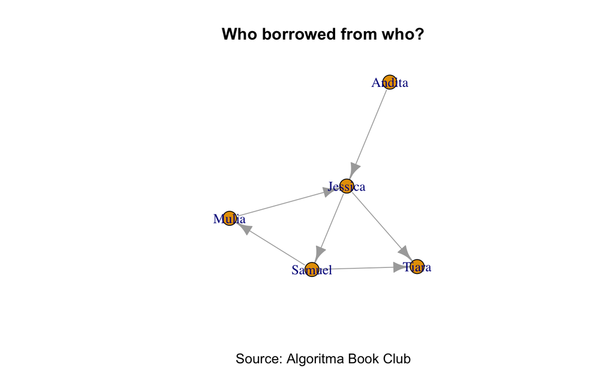

## Demo: Visualizing ZeuS Botnet

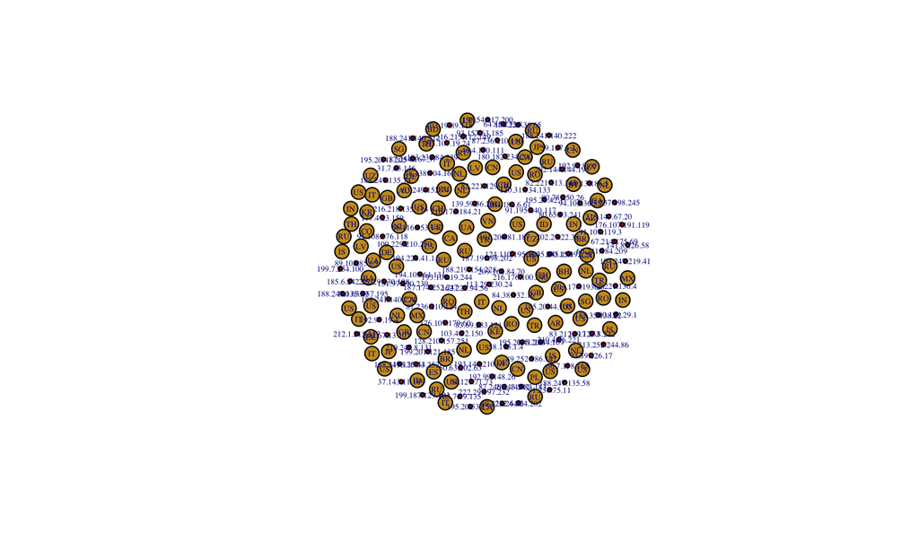

## Demo: Visualizing ZeuS Botnet

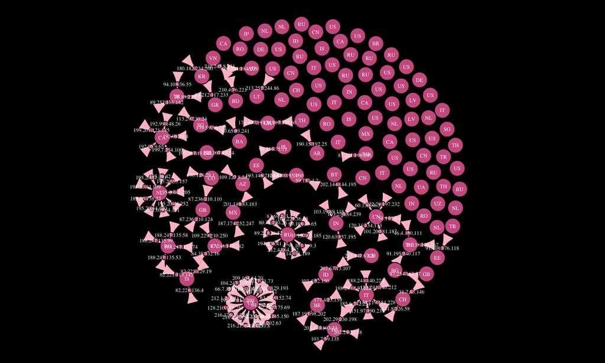

## Demo: `tkplot`

```r
tkplot(g)
```

## Case Study: Security Incidents

## Background: VERIS

The vocabulary for event recording and incident sharing. VERIS is a response to one of the most critical and persistent challenges in the security industry - a lack of quality information. VERIS targets this problem by helping organizations to collect useful incident-related information and to share that information - anonymously and responsibly - with others.

## System for Post-Incidents Investigation

### Concepts

4 A’s of Incident Details: - Who is behind an incident (`Actor`)  
- Methods uses (`Action`)  
- Devices affected (`Asset`)  
- How they were affected (`Attribute`)

Aspects of Narrative: - Incident Tracking  
- Victim Demographics  
- Incident Description  
- Discovery & Response  
- Impact Assessment

### Tools we’ll use:

- VCDB Community Database
- `verisr2`
- Exploratory Data Analysis tools in R

## Flexibility and Form

The design challenge with a “common language” for security incidents are twofold:

- Structuredness around schema
- Extensibility (evolving schema)

## Flexibility and Form

[figure not shown]

**This resulted in data structures that might be pretty *awkward* to work with.**

Thankfully, we have R.

## Demo: JSON directory to CSV

```r
# install devtools
devtools::install_github("onlyphantom/verisr2")
```

```r
library(verisr2)
data(vcdb)
```

To read from a directory containing incidents in JSON, use `importveris(".../json_file_path")`

## Indonesia-related security incidents

```r
id <- involving_country(vcdb, "ID", notes_only=TRUE)
rownames(id) <- NULL
id[,c("summary", "actor.external.notes")]
```

| summary | actor.external.notes |
| --- | --- |
| 2 governmental websites defaced by unaffiliated external actor. | NA |
| The Australian Federal Police and the Reserve Bank of Austrailia were victims of a DoS attack. | anonymous indonesia |
| Incident associated with Red October campaign. Phishing email with malware attachment leading to infection, C2, credential compromise, and lateral movement through network. Goal to steal classified in… | Basing on registration data of C&C servers and numerous artifacts left in executables of the malware, we strongly believe that the attackers have Russian-speaking origins. Current attackers and execut… |
| Two Indonesian hackers going with the handle of SultanHaikal and Brian Kamikaze have hacked and defaced total 627 random websites under the banner of #OpFreeSyria. Among the hacked websites, 36 belong… | RedHack |
| A group of Indonesian hackers going with the handle of Gantengers Crew have hacked and defaced the official website of Yemens Ministry of Human Rights, United Nations Development Programme (UNDP), Uni… | anonymous |
| The official blog of USEmbassy.gov a portal for US embassies, consulates and diplomatic missions has been hacked and defaced by an Indonesian hacker using the online moniker Dbuzz. | Anonymous Peru |
| State Department website defaced by Dbuzz (unaffiliated hacker). | NA |
| DDoS on central bank | n a YouTube video posted in early May, Anonymous said it would launch a 30-day campaign to attack central bank sites in what it dubbed as Operation Icarus |
| Indonesian hackers from the group Gantengers Crew hacked and defaced MasterCard's website. | NA |
| ATM skimming in Jakarta, Java, Bank there re-issued millions of debit cards over the incident. Identified through internal fraud, no mention of finding the skimmer on ATM(s). | NA |

[output cut: 3 more lines]

## EDA and Visualization Demo

Works well with other packages from `tidyverse()`:

```r
id <- involving_country(vcdb, "ID")
us <- involving_country(vcdb, "US")
dat <- rbind(id, us)
attacks <- enum2grid(dat, c("action", "asset.variety"))
class(attacks)
```

```
## [1] "gg"     "ggplot"
```

## EDA and Visualization Demo

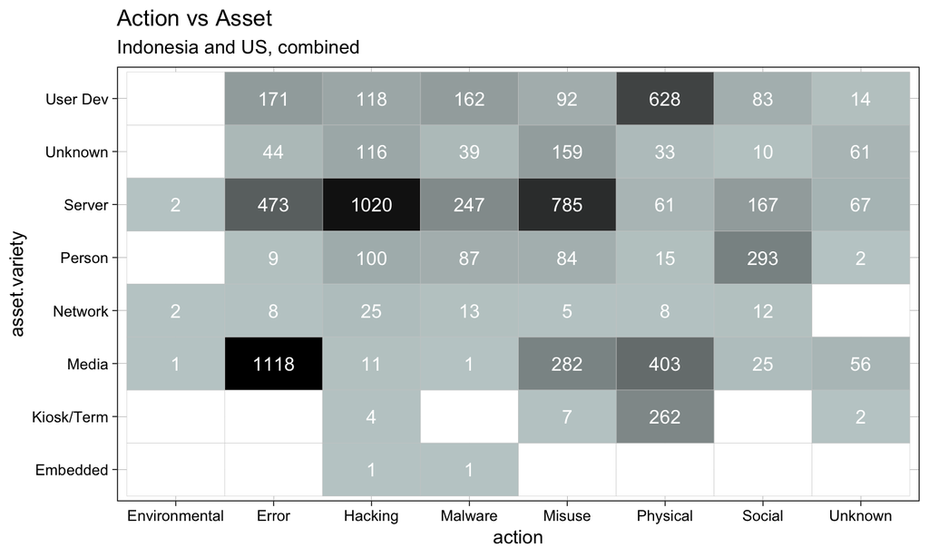

```r
attacks +
  ggplot2::labs(title="Action vs Asset", subtitle="Indonesia and US, combined") +
  ggplot2::theme(legend.position = "none")
```

## Next Steps

- Install R and RStudio
- Install `verisr2` and [read the examples](http://github.com/onlyphantom/verisr2)
- Download examples from [my Github](http://github.com/onlyphantom) and [materials by Tiara](http://github.com/tiaradwiputri)
- Show your skills off building a project using the `veris` dataset
  - Can be a Shiny web app, HTML (knitted from R Markdown), visualization, blog article, pull request, any other format of work

## Next Steps

- Put your work in front of people
  - Even better: Let me *promote* it for you, gallery / newsletter-featured style
- Interested to solve data science problems for companies? Send me your work!
  - Email: samuel@algorit.ma
  - LinkedIn: Samuel Chan
  - GitHub: OnlyPhantom
  - StackOverflow: OnlyPhantom
  - Any other platform you find me on